# London Household Income: WFH and Education Analysis

Author

Gemini CLI Researcher

## Introduction

This report analyzes the distribution of disposable household income across London. We examine the spatial patterns by borough, the relationship between education and income, and a focused analysis of how pandemic-era work-from-home (WFH) patterns relate to income levels in 2023.

## Interactive Map of Disposable Household Income

Explore the spatial distribution of net annual household income. Hover for details on Borough and WFH rates.

[interactive chart not shown]

## Education and Household Income

As a contextual factor, we observe the relationship between the percentage of residents with high-level qualifications (Level 4+) and household income.

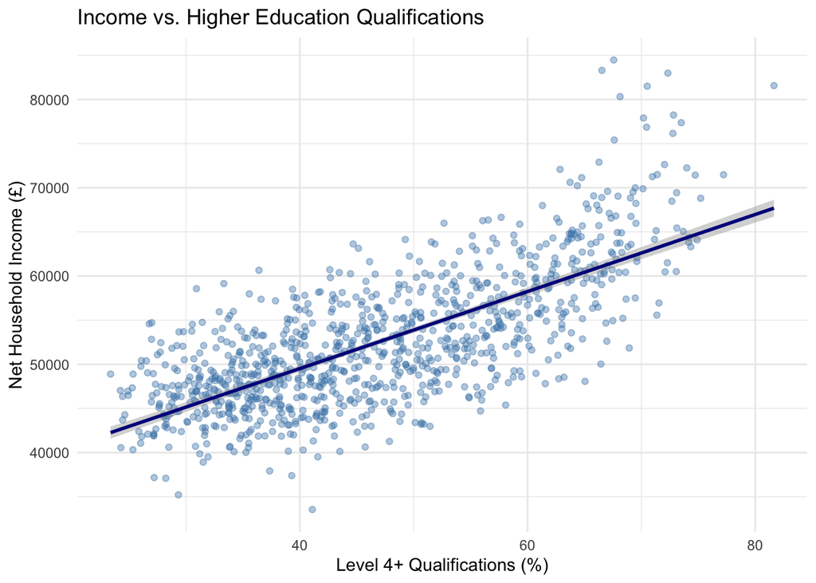

## The Impact of COVID-Era Work Patterns

Focusing on the 2020-2023 period, we analyze how “Working mainly at or from home” (as measured in the 2021 Census) relates to 2023 disposable income.

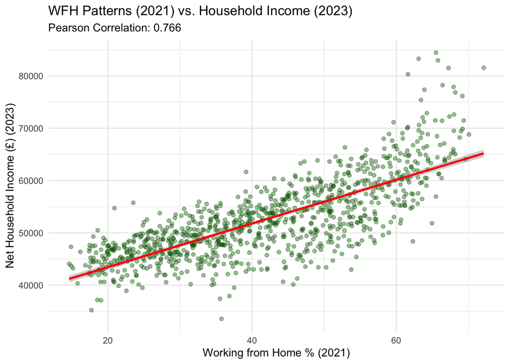

## Summary of Findings

The analysis demonstrates a strong spatial concentration of wealth in Central and West London. Contextually, education remains a significant correlate of income. However, focusing on the COVID-19 impact, we find a robust positive correlation (r = 0.766) between 2021 WFH rates and 2023 disposable income. The linear model suggests that for every **10% increase** in an area’s WFH rate in 2021, the average 2023 disposable household income is approximately **£4,174 higher**. This underscores how the economic structure of London areas—specifically their capacity for remote work—is a primary differentiator of household income levels in the post-pandemic landscape.